# Bioinformatics Final Project

Chiayu, Katlheen, Paola

2025-04-11

## Install and Load libraries

```r
#install vegan package
#install.packages('vegan',repos=('https://vegandevs.r-universe.dev','https://cloud.r-project.org'))

#load
library(tibble)
library(vegan)
library(tidyverse)
library(rstatix)
library(ggpubr)
```

## Initializator

```r
store_vectors<- list()
filename<-vector()
```

## Open Data and Preprocessing

```r
#open files in the directory
file_list<-list.files("~/Documents/Data_04.02/kraken2_results/", pattern = "\\.csv$", full.names = TRUE)

###create a otu table
for(i in file_list){
    #open data
    data= read.csv(i,header=T)

    #name of the file to store
    name<- sub("\\_species.csv$", "", basename(i))
    filename<- append(filename,name)
    #vector contain taxon name  and clade_reads
    otu_vector <- setNames(data$reads_clade, data$name)

    #convert in 1-row dataframe
    otu_table <- as.data.frame(t(otu_vector))

    #store vector in a list of vectors
    store_vectors[[name]] <- otu_table}


otu_table <- bind_rows(store_vectors) %>%
  replace(is.na(.), 0)

rownames(otu_table)<-filename

###create metadata
metadata<-as.data.frame(rownames(otu_table))
metadata$country<-ifelse(grepl("^E", metadata$`rownames(otu_table)`), "USA", "Asia")
colnames(metadata)<-c("sample","country")
```

## Alpha Diversity

### Shannon

```r
shannon <- diversity(otu_table, index = "shannon")
shannon_df<- data.frame(shannon,country = metadata$country)
```

### Check data normality

> The normality evaluation below shows p-value < 0.05 for Asia, thus the alternative hypothesis that Asia metagenome data does not follow normal distribution. On the other hand, USA metagenome data follow normally distribution (p > 0.05). Since one group does not follow normal distribution we consider a non-parametric test for comparison (Wilcxon-test).

```r
shapiro.test(shannon_df$shannon[shannon_df$country =="Asia"])
```

```
##
##  Shapiro-Wilk normality test
##
## data:  shannon_df$shannon[shannon_df$country == "Asia"]
## W = 0.60426, p-value = 6.217e-05
```

```r
shapiro.test(shannon_df$shannon[shannon_df$country =="USA"])
```

```
##
##  Shapiro-Wilk normality test
##
## data:  shannon_df$shannon[shannon_df$country == "USA"]
## W = 0.94356, p-value = 0.5932
```

### Wilcox test- Shannon

> The comparison demonstrates that the null hypothesis is rejected (p-value < 0.05). Thus, there is statiscal difference in diversity between the countries. The chart above shows that the average diveristy is higher in Asia compared to USA.It indicates that there is difference in diversity between the two regions.

```r
wilcox.test(shannon ~ country, data = shannon_df)
```

```
##
##  Wilcoxon rank sum exact test
##
## data:  shannon by country
## W = 100, p-value = 1.083e-05
## alternative hypothesis: true location shift is not equal to 0
```

### Shannon Diversity visualization

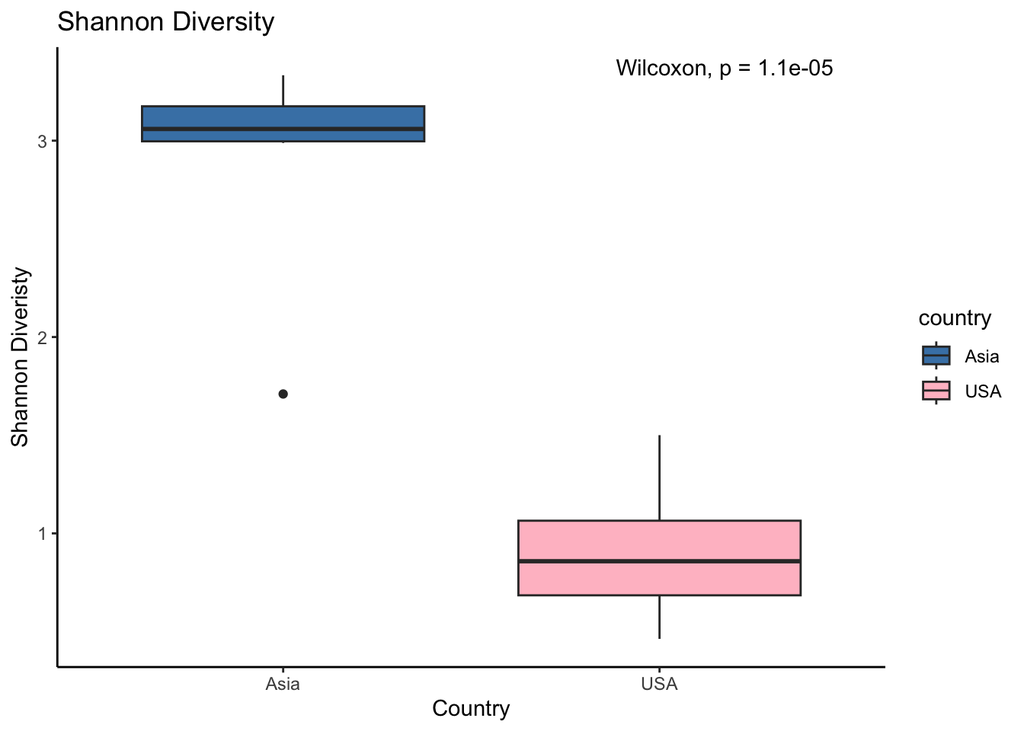

```r
ggplot(shannon_df, aes(x = country, y = shannon, fill = country)) +
  geom_boxplot()+
  labs(title="Shannon Diversity", y="Shannon Diveristy", x="Country")+
  scale_fill_manual(values=c("steelblue", "pink"))+
  theme_bw() +
  theme(axis.line = element_line(colour = "black"),
    panel.grid.major = element_blank(),
    panel.grid.minor = element_blank(),
    panel.border = element_blank(),
    panel.background = element_blank())+
  stat_compare_means(method = "wilcox.test",label.x.npc = "right")
```

### Richness

```r
richness <- specnumber(otu_table)
richness_df<- data.frame(richness,country = metadata$country)
```

### T-test - Richeness

> Even though Asia shows an average richness higher than USA, no statiscal difference was oberserved in number of species between these two countries.

```r
t.test(richness ~ country, data = richness_df)
```

```
##
##  Welch Two Sample t-test
##
## data:  richness by country
## t = 1.4049, df = 15.526, p-value = 0.1797
## alternative hypothesis: true difference in means between group Asia and group USA is not equal to 0
## 95 percent confidence interval:
##  -15.48231  75.88231
## sample estimates:
## mean in group Asia  mean in group USA
##              159.4              129.2
```

### Richeness visualization

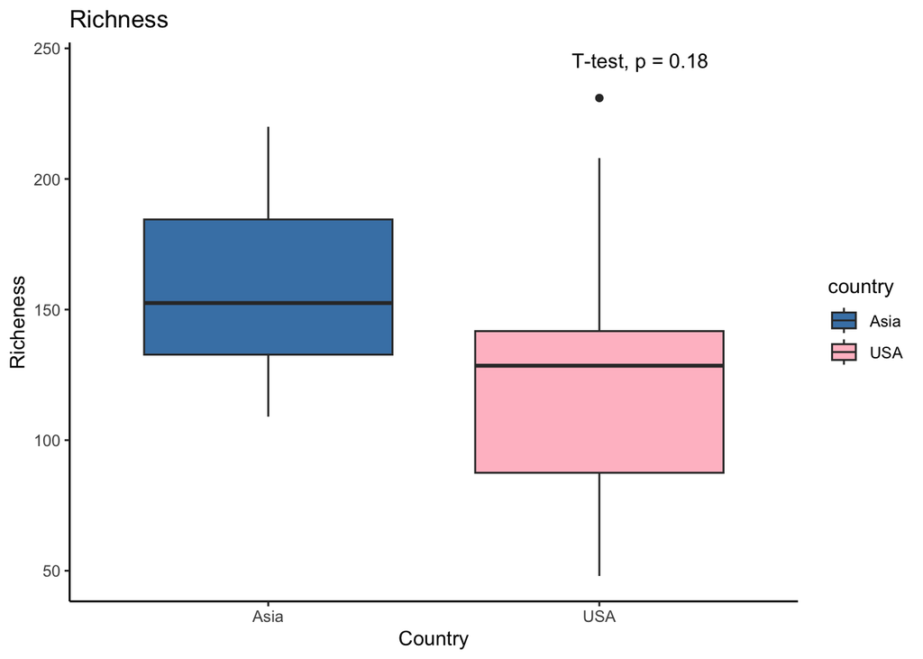

```r
ggplot(richness_df, aes(x = country, y = richness, fill = country)) +
  geom_boxplot()+
  labs(title="Richness", y="Richeness", x="Country")+
  scale_fill_manual(values=c("steelblue", "pink"))+
  theme_bw() +
  theme(axis.line = element_line(colour = "black"),
    panel.grid.major = element_blank(),
    panel.grid.minor = element_blank(),
    panel.border = element_blank(),
    panel.background = element_blank())+
  stat_compare_means(method = "t.test",label.x.npc = "right",
                     label.y = max(richness_df$richness) * 1.05)
```

### Eveness

```r
evenness = shannon / log(richness)
evenness_df<- data.frame(evenness,country = metadata$country)
```

### Check data normality

> The normality evaluation below shows p-value < 0.05 for Asia, thus the alternative hypothesis that Asia metagenome data does not follow normal distribution. On the other hand, USA metagenome data follow normally distribution (p > 0.05). Since one group does not follow normal distribution we consider a non-parametric test for comparison (Wilcxon-test).

```r
shapiro.test(evenness_df$evenness[evenness_df$country =="Asia"])
```

```
##
##  Shapiro-Wilk normality test
##
## data:  evenness_df$evenness[evenness_df$country == "Asia"]
## W = 0.7361, p-value = 0.002417
```

```r
shapiro.test(evenness_df$evenness[evenness_df$country =="USA"])
```

```
##
##  Shapiro-Wilk normality test
##
## data:  evenness_df$evenness[evenness_df$country == "USA"]
## W = 0.94822, p-value = 0.6475
```

### Wilcox test- Evenness

```r
wilcox.test(evenness ~ country, data = evenness_df)
```

```
##
##  Wilcoxon rank sum exact test
##
## data:  evenness by country
## W = 100, p-value = 1.083e-05
## alternative hypothesis: true location shift is not equal to 0
```